# STA_445_HW3

Lauren Eisele-Yocum

2026-10-16

## Exercises

### Exercise 1

Write a function that calculates the density function of a Uniform continuous variable on the interval $\left(a,b\right)$. The uniform density function is defined as

$$f\left(x\right)=\begin{cases}
\frac{1}{b-a} & \;\;\;\textrm{if }a\le x\le b\\
0 & \;\;\;\textrm{otherwise}
\end{cases}$$
which looks like this

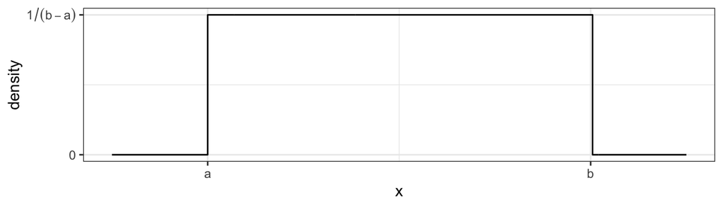

Your goal for this exercise is to write a function `duniform(x, a, b)` that takes an arbitrary value of `x` and parameters `a` and `b` and returns the appropriate height of the density function ($1/(b-a)$). For various values of `x`, `a`, and `b`, demonstrate that your function returns the correct density value.

I first assigned values to a and b. I then created a function using if_else statements to return the height of a uniform distribution. I then ran the values, 8,1, and 11 to check if my function worked.

**a)** Write your function without regard for it working with vectors of data. Demonstrate that it works by calling the function three times, once where $x< a$, once where $a < x < b$, and finally once where $b < x$.

```r
a <- 3
b <- 9

unif_fun <- function(x){
  if( x < a ){
  result <- 0
  }else if( x <= b ){
  result <- 1/(b-a)
  }else{
  result <- 0
  }
  return(result)}

unif_fun(8)
```

```
## [1] 0.1666667
```

```r
unif_fun(1)
```

```
## [1] 0
```

```r
unif_fun(11)
```

```
## [1] 0
```

I assigned values to a and b, and then used if else logic to satisfy the parameters uniform function. I then tested if my function worked by running x values of 8, 1, and 11

**b)** Next lets improve our function to work correctly for a vector of `x` values. Modify your function in part (a) so that the core logic uses a `for`-loop statement and the loop moves through each element of `x` in succession. Since this is a bit more of a complex task, your function should look something like this:

```r
duniform <- function(x, a, b){
  result <- NULL
  N <- length(x)
  for( i in 1:N ){
     if( x[i] < b & x[i] > a ){
  result[i] <- 1/(b-a)
    }else{
  result[i] <- 0
  }
  }
  return(result)
}

duniform(x=seq(1, 20, length.out=10), 12, 24)
```

```
##  [1] 0.00000000 0.00000000 0.00000000 0.00000000 0.00000000 0.00000000
##  [7] 0.08333333 0.08333333 0.08333333 0.08333333
```

I created a new function (duniform) using a loop and if else logic to satusfy the uniform function so that I could run a vector through the loop . I also used x[i] to vectorize x. I then tested my function using a sequence function to create a vector of values to run through the function.

Verify that your function works correctly by running the following code:

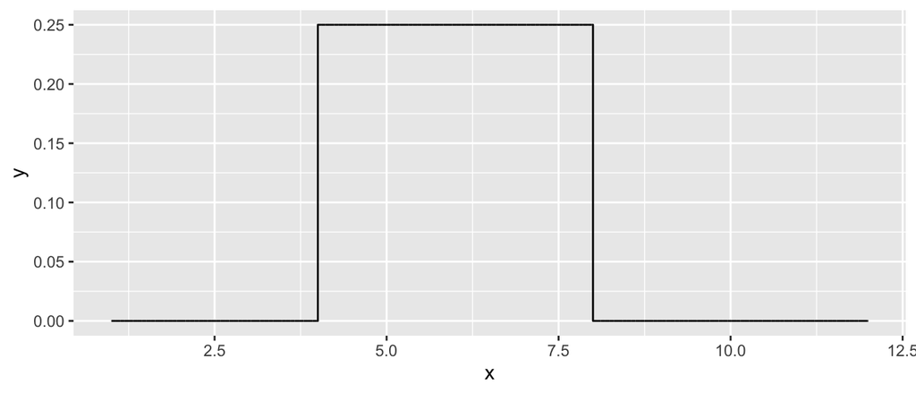

```r
data.frame( x=seq(1, 12, by=.001) ) %>%
  mutate( y = duniform(x, 4, 8) ) %>%
  ggplot( aes(x=x, y=y) ) +
  geom_step()
```

I used ggplot and geom_step to graph my uniform distribution.

**c)** Install the R package `microbenchmark`. We will use this to discover the average duration (time) your function takes to execute code. Execute the following

```r
microbenchmark::microbenchmark( duniform( seq(-4,12,by=.0001), 4, 8), times=100)
```

```
## Unit: milliseconds
##                                     expr      min       lq     mean   median
##  duniform(seq(-4, 12, by = 1e-04), 4, 8) 54.30126 54.77161 57.07491 55.61326
##        uq      max neval
##  56.47707 116.2784   100
```

I installed microbenchmark in the console, the loaded the library and ran microbenchmark on my function with a loop.

This will call the input R expression (your `duniform` function on a rather large vector of data) 100 times and report summary statistics on how long it took for the code to run. In particular, look at the median time for evaluation.

**d)** Instead of using a `for` loop, it might have been easier to use an `ifelse()` command, which inherently accepts vectors. Rewrite your function one last time, this time avoiding the `for` loop and instead introducing the *vectorizable* `ifelse()` command. Verify that your function works correctly by producing a plot of a uniform density. Finally, run the `microbenchmark()` code above again.

```r
uni_fun2 <- function(x, a, b){
  result = NULL
    ifelse( a<=x & x<=b, 1/(b-a), 0 )
    result = result
  return(result)
}
```

```r
microbenchmark::microbenchmark( uni_fun2( seq(-4,12,by=.0001), 4, 8), times=100)
```

```
## Unit: milliseconds
##                                     expr      min       lq     mean   median
##  uni_fun2(seq(-4, 12, by = 1e-04), 4, 8) 3.643547 3.689549 4.916197 3.778663
##        uq      max neval
##  4.961717 66.47523   100
```

**e)** Comment on Which version of your function was easier to write? Which ran faster?

The second version was much easier to run than the second function.

### Exercise 2

I very often want to provide default values to a parameter that I pass to a function. For example, it is so common for me to use the `pnorm()` and `qnorm()` functions on the standard normal, that R will automatically use `mean=0` and `sd=1` parameters unless you tell R otherwise. This was discussed significantly in the chapter above. To get that behavior, we can set the default parameter values in the definition of a function. When the function is called, the user specified value is used, but if none is specified, the defaults are used. Look at the help page for the functions `dunif()`, and notice that there are a number of default parameters.

For your `duniform()` function provide default values of `0` and `1` for the arguments `a` and `b`. Demonstrate that your function is appropriately using the given default values by producing a graph of the density without specifying the `a` or `b` arguments.

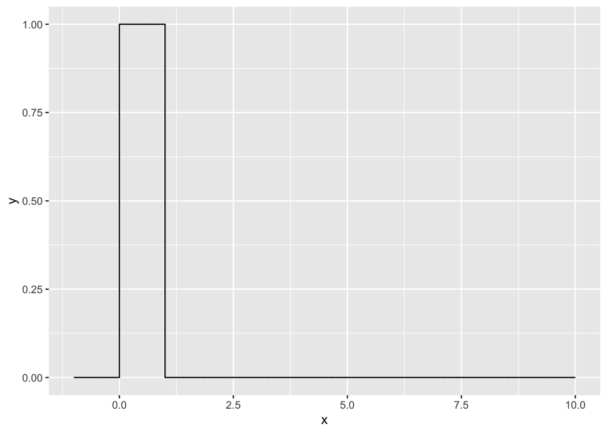

```r
duniform <- function(x,a=0,b=1){
    result = NULL
    result <- ifelse( a<=x & x<=b, 1/(b-a), 0 )
  return(result)
}

data.frame( x=seq(-1, 10, by=.001) ) %>%
  mutate( y = duniform(x) ) %>%
  ggplot( aes(x=x, y=y) ) +
  geom_step()
```

I provided the default of a=0 and b=1, and updated the function. Then I plotted the uniform distribution using the default values I set.

### Exercise 3

A common data processing step is to *standardize* numeric variables by subtracting the mean and dividing by the standard deviation. Mathematically, the standardized value is defined as

$$z = \frac{x-\bar{x}}{s}$$

where $\bar{x}$ is the mean and $s$ is the standard deviation.

**a)** Create a function that takes an input vector of numerical values and produces an output vector of the standardized values.

```r
standardize <- function(x){
  mu = mean(x)
  se = sd(x)
  z  = (x - mu)/se
  return(z)
}

standardize(1:10)
```

```
##  [1] -1.4863011 -1.1560120 -0.8257228 -0.4954337 -0.1651446  0.1651446
##  [7]  0.4954337  0.8257228  1.1560120  1.4863011
```

I created a standardize function, and then tested it on 1:10.

**b)** Apply this function to each numeric column in a data frame using the `dplyr::across()` or the `dplyr::mutate_if()` commands. *This is often done in model algorithms that rely on numerical optimization methods to find a solution. By keeping the scales of different predictor covariates the same, the numerical optimization routines generally work better.* Below is some code that should really help once your `standardize()` function is working. The graphs may not look very different, but pay attention to the x- and y-axis scales!

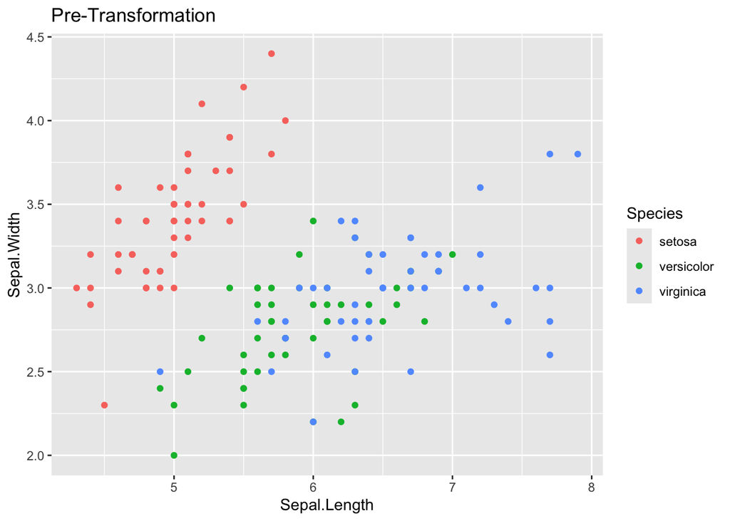

```r
data( 'iris' )
# Graph the pre-transformed data.
ggplot(iris, aes(x=Sepal.Length, y=Sepal.Width, color=Species)) +
  geom_point() +
  labs(title='Pre-Transformation')
```

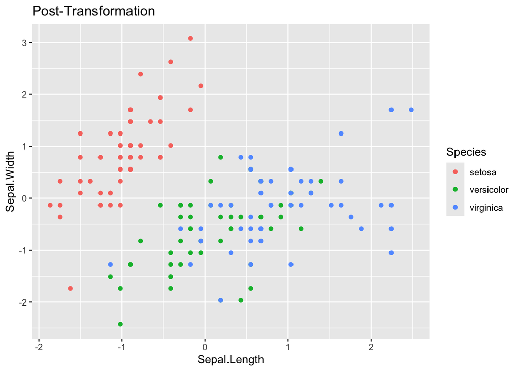

```r
# Standardize all of the numeric columns
# across() selects columns and applies a function to them
# there column select requires a dplyr column select command such
# as starts_with(), contains(), or where().  The where() command
# allows us to use some logical function on the column to decide
# if the function should be applied or not.
iris.z <- iris %>% mutate( across(where(is.numeric), standardize) )

# Graph the post-transformed data.
ggplot(iris.z, aes(x=Sepal.Length, y=Sepal.Width, color=Species)) +
  geom_point() +
  labs(title='Post-Transformation')
```

The difference between these two plots does not initially look different, but their axes are different.

### Exercise 4

In this exercise, you’ll write a function that will output a vector of the first $n$ terms in the child’s game *Fizz Buzz*. Your function should only accept the argument $n$, the number to which you wish to count.

Here is a description of the game. The goal is to count as high as you can but substitute in the words `Fizz`, `Buzz` or `Fizz-Buzz` depending on the divisors of the number. Specifically, any number evenly divisible by $3$ should be substituted by “Fizz”, any number evenly divisible by $5$ substituted by “Buzz”, and if the number is divisible by both $3$ and $5$ (i.e. by $15$) substitute “Fizz-Buzz”. So a sequence of integers output by your function should look like

$$1, 2, Fizz, 4, Buzz, Fizz, 7, 8, Fizz, \dots$$

```r
FizzBuzz <- function(n){
  output <- 1:n
{for(i in output){
  if(i %% 3 == 0 & i %% 5 == 0) output[i] <- 'Fizz-Buzz'
  if(i %% 3 == 0 & i %% 5 != 0) output[i] <- 'Fizz'
  if(i %% 3 != 0 & i %% 5 == 0) output[i] <- 'Buzz'
  if(i %% 3 != 0 & i %% 5 != 0) output[i] <-  i}
}
  return(output)
}

FizzBuzz(10)
```

```
##  [1] "1"    "2"    "Fizz" "4"    "Buzz" "Fizz" "7"    "8"    "Fizz" "Buzz"
```

I had a lot of trouble with this problem intially but ran everything in an rscript to make sure the if statements were working after I assigned a, b and i values. I was then able to add it into my created function. I then tested if my function worked by inputting an n value.

*Hint: The `paste()` function will squish strings together. The remainder operator is `%%` where it is used as `9 %% 3 = 0`.*

This problem was inspired by a wonderful YouTube [video](https://www.youtube.com/watch?v=QPZ0pIK_wsc) that describes how to write an appropriate loop to do this in JavaScript, but it should be easy enough to interpret what to do in R. I encourage you to try to write your function first before watching the video.